```python
#Import and read the file
import pandas as pd
import matplotlib.pyplot as plt
import urllib.request, urllib.parse, urllib.error
import json

rf = pd.read_csv("ramen_ratings.csv")
rf.info()
```

```
<class 'pandas.core.frame.DataFrame'>
RangeIndex: 2580 entries, 0 to 2579
Data columns (total 7 columns):
Review #    2580 non-null int64
Brand       2580 non-null object
Variety     2580 non-null object
Style       2578 non-null object
Country     2580 non-null object
Stars       2580 non-null object
Top Ten     41 non-null object
dtypes: int64(1), object(6)
memory usage: 141.2+ KB
```

# Data Visualization

The users can check the top ten countries based on number of the brands such as: Japan, USA, South Korea, Taiwan, Thailand, China, Malaysia, Hong Kong, Indonesia, Singapore. The users can check the styles, brands, and flavors of ramen for the top 10 countries. Also, they can see the top 10 countries with highest stars.

We also include the graphs for the total consumption of ramen from 2014 - 2018 for the top 10 countries (We do not import this dataset. Instead, we created a dataframe for each country)

## Ramen Ratings

### Top Ten Countries

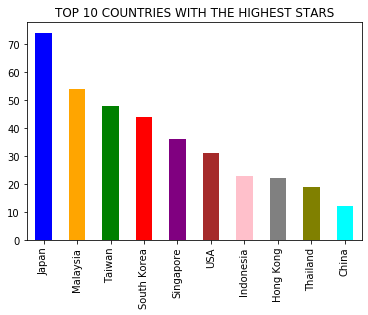

```python
#Top 10 countries with highest stars
first_ten = rf[rf.Stars == "5"]
first_ten = first_ten.Country.value_counts()
first_ten.head(10).plot.bar(color=["blue", "orange", "green", "red", "purple", "brown", "pink", "gray", "olive", "cyan"])
plt.title("TOP 10 COUNTRIES WITH THE HIGHEST STARS")
```

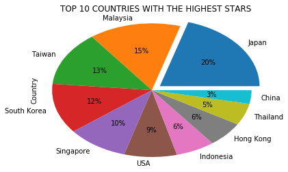

```python
#Pie chart
first_ten.head(10).plot.pie(explode=(0.1,0,0,0,0,0,0,0,0,0),autopct="%1.0f%%")
plt.axis("tight")
plt.title("TOP 10 COUNTRIES WITH THE HIGHEST STARS")
```

### Japan

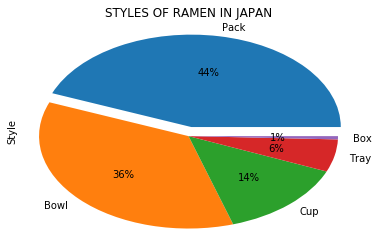

```python
#Styles of ramen in Japan
japan = rf[rf.Country == "Japan"]
style_japan = japan.Style.value_counts()
style_japan.plot.pie(explode=(0.1,0,0,0,0),autopct="%1.0f%%")
plt.axis("tight")
plt.title("STYLES OF RAMEN IN JAPAN")
```

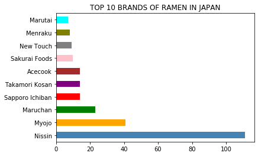

```python
#Top 10 brands of ramen in Japan
brand_japan = japan.Brand.value_counts().head(10)
brand_japan.plot.barh(color=["steelblue", "orange", "green", "red", "purple", "brown", "pink", "gray", "olive", "cyan"])
plt.title("TOP 10 BRANDS OF RAMEN IN JAPAN")
```

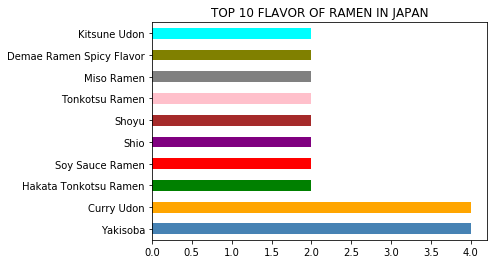

```python
#Top 10 flavor of ramen in Japan
variety_japan = japan.Variety.value_counts().head(10)
variety_japan.plot.barh(color=["steelblue", "orange", "green", "red", "purple", "brown", "pink", "gray", "olive", "cyan"])
plt.title("TOP 10 FLAVOR OF RAMEN IN JAPAN")
```

### USA

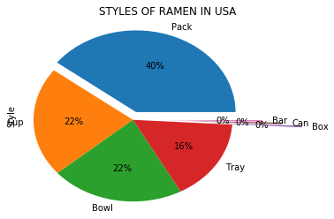

```python
#Styles of ramen in USA
usa = rf[rf.Country == "USA"]
style_usa = usa.Style.value_counts()
style_usa.plot.pie(explode=(0.1,0,0,0,0.7,0.5,0.3),autopct="%1.0f%%")
plt.axis("tight")
plt.title("STYLES OF RAMEN IN USA")
```

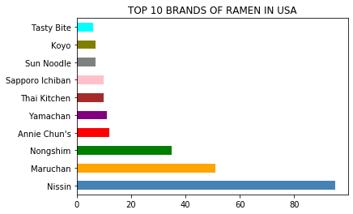

```python
#Top 10 brands of ramen in USA
brand_usa = usa.Brand.value_counts().head(10)
brand_usa.plot.barh(color=["steelblue", "orange", "green", "red", "purple", "brown", "pink", "gray", "olive", "cyan"])
plt.title("TOP 10 BRANDS OF RAMEN IN USA")
```

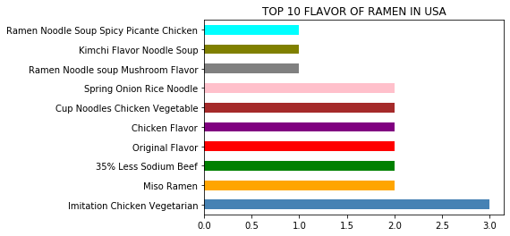

```python
#Top 10 flavor of ramen in USA
variety_usa = usa.Variety.value_counts().head(10)
variety_usa.plot.barh(color=["steelblue", "orange", "green", "red", "purple", "brown", "pink", "gray", "olive", "cyan"])
plt.title("TOP 10 FLAVOR OF RAMEN IN USA")
```

### South Korea

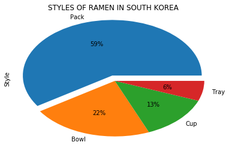

```python
#Styles of ramen in South Korea
southk = rf[rf.Country == "South Korea"]
style_southk = southk.Style.value_counts()
style_southk.plot.pie(explode=(0.1,0,0,0),autopct="%1.0f%%")
plt.axis("tight")
plt.title("STYLES OF RAMEN IN SOUTH KOREA")
```

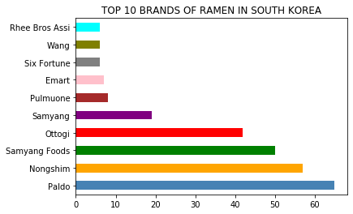

```python
#Top 10 brands of ramen in South Korea
brand_southk = southk.Brand.value_counts().head(10)
brand_southk.plot.barh(color=["steelblue", "orange", "green", "red", "purple", "brown", "pink", "gray", "olive", "cyan"])
plt.title("TOP 10 BRANDS OF RAMEN IN SOUTH KOREA")
```

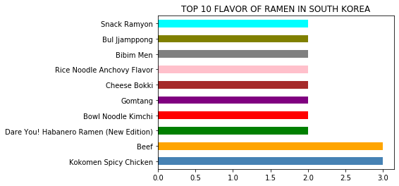

```python
#Top 10 flavor of ramen in South Korea
variety_southk = southk.Variety.value_counts().head(10)
variety_southk.plot.barh(color=["steelblue", "orange", "green", "red", "purple", "brown", "pink", "gray", "olive", "cyan"])
plt.title("TOP 10 FLAVOR OF RAMEN IN SOUTH KOREA")
```

### Taiwan

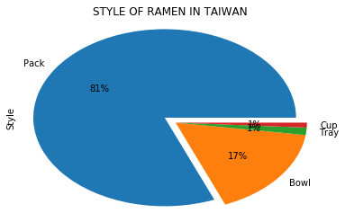

```python
#Styles of ramen in Taiwan
taiwan = rf[rf.Country == "Taiwan"]
style_taiwan = taiwan.Style.value_counts()
style_taiwan.plot.pie(explode=(0.1,0,0,0),autopct="%1.0f%%")
plt.axis("tight")
plt.title("STYLE OF RAMEN IN TAIWAN")
```

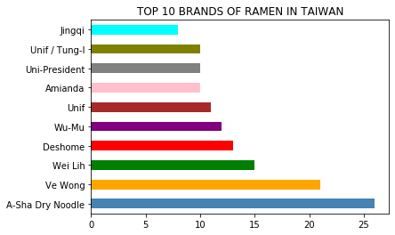

```python
#Top 10 brands of ramen in Taiwan
brand_taiwan = taiwan.Brand.value_counts().head(10)
brand_taiwan.plot.barh(color=["steelblue", "orange", "green", "red", "purple", "brown", "pink", "gray", "olive", "cyan"])
plt.title("TOP 10 BRANDS OF RAMEN IN TAIWAN")
```

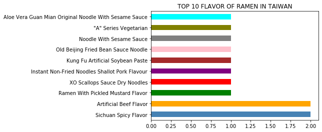

```python
#Top 10 flavor of ramen in Taiwan
variety_taiwan = taiwan.Variety.value_counts().head(10)
variety_taiwan.plot.barh(color=["steelblue", "orange", "green", "red", "purple", "brown", "pink", "gray", "olive", "cyan"])
plt.title("TOP 10 FLAVOR OF RAMEN IN TAIWAN")
```

### Thailand

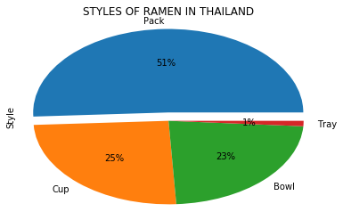

```python
#Styles of ramen in Thailand
thailand = rf[rf.Country == "Thailand"]
style_thailand = thailand.Style.value_counts()
style_thailand.plot.pie(explode=(0.1,0,0,0),autopct="%1.0f%%")
plt.axis("tight")
plt.title("STYLES OF RAMEN IN THAILAND")
```

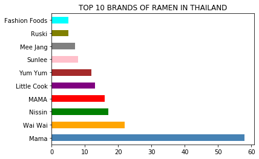

```python
#Top 10 brands of ramen in Thailand
brand_thailand = thailand.Brand.value_counts().head(10)
brand_thailand.plot.barh(color=["steelblue", "orange", "green", "red", "purple", "brown", "pink", "gray", "olive", "cyan"])
plt.title("TOP 10 BRANDS OF RAMEN IN THAILAND")
```

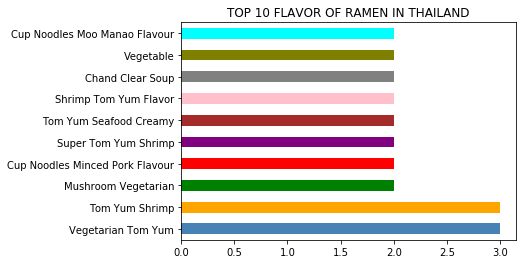

```python
#Top 10 flavor of ramen in Thailand
variety_thailand = thailand.Variety.value_counts().head(10)
variety_thailand.plot.barh(color=["steelblue", "orange", "green", "red", "purple", "brown", "pink", "gray", "olive", "cyan"])
plt.title("TOP 10 FLAVOR OF RAMEN IN THAILAND")
```

### China

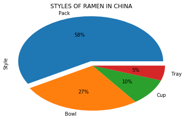

```python
##Styles of ramen in China
china = rf[rf.Country == "China"]
style_china = china.Style.value_counts()
style_china.plot.pie(explode=(0.1,0,0,0),autopct="%1.0f%%")
plt.axis("tight")
plt.title("STYLES OF RAMEN IN CHINA")
```

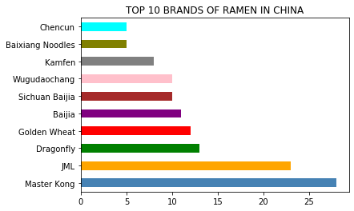

```python
#Top 10 brands of ramen in China
brand_china = china.Brand.value_counts().head(10)
brand_china.plot.barh(color=["steelblue", "orange", "green", "red", "purple", "brown", "pink", "gray", "olive", "cyan"])
plt.title("TOP 10 BRANDS OF RAMEN IN CHINA")
```

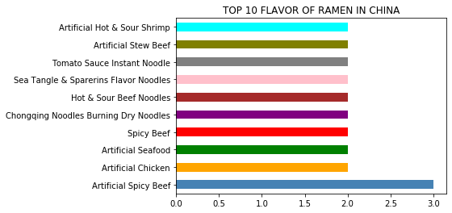

```python
#Top 10 flavor of ramen in China
variety_china = china.Variety.value_counts().head(10)
variety_china.plot.barh(color=["steelblue", "orange", "green", "red", "purple", "brown", "pink", "gray", "olive", "cyan"])
plt.title("TOP 10 FLAVOR OF RAMEN IN CHINA")
```

### Malaysia

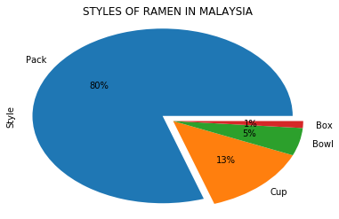

```python
#Styles of ramen in Malaysia
malaysia = rf[rf.Country == "Malaysia"]
style_malaysia = malaysia.Style.value_counts()
style_malaysia.plot.pie(explode=(0.1,0,0,0),autopct="%1.0f%%")
plt.axis("tight")
plt.title("STYLES OF RAMEN IN MALAYSIA")
```

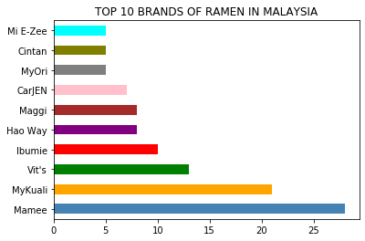

```python
#Top 10 brands of ramen in Malaysia
brand_malaysia = malaysia.Brand.value_counts().head(10)
brand_malaysia.plot.barh(color=["steelblue", "orange", "green", "red", "purple", "brown", "pink", "gray", "olive", "cyan"])
plt.title("TOP 10 BRANDS OF RAMEN IN MALAYSIA")
```

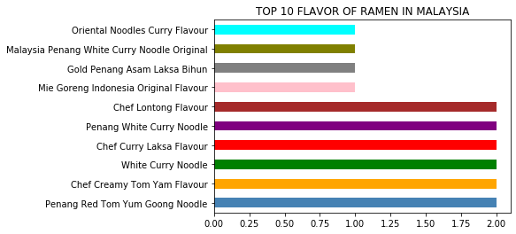

```python
#Top 10 flavor of ramen in Malaysia
brand_malaysia = malaysia.Variety.value_counts().head(10)
brand_malaysia.plot.barh(color=["steelblue", "orange", "green", "red", "purple", "brown", "pink", "gray", "olive", "cyan"])
plt.title("TOP 10 FLAVOR OF RAMEN IN MALAYSIA")
```

### Hong Kong

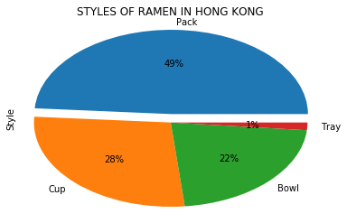

```python
#Styles of ramen in Hong Kong
hongkong = rf[rf.Country == "Hong Kong"]
style_hongkong = hongkong.Style.value_counts()
style_hongkong.plot.pie(explode=(0.1,0,0,0),autopct="%1.0f%%")
plt.axis("tight")
plt.title("STYLES OF RAMEN IN HONG KONG")
```

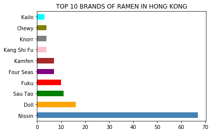

```python
#Top 10 brands of ramen in Hong Kong
brand_hongkong = hongkong.Brand.value_counts().head(10)
brand_hongkong.plot.barh(color=["steelblue", "orange", "green", "red", "purple", "brown", "pink", "gray", "olive", "cyan"])
plt.title("TOP 10 BRANDS OF RAMEN IN HONG KONG")
```

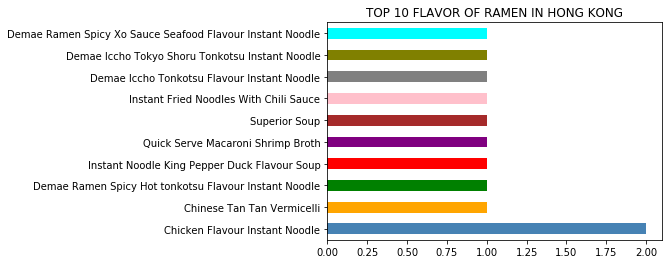

```python
#Top 10 flavor of ramen in Hong Kong
variety_hongkong = hongkong.Variety.value_counts().head(10)
variety_hongkong.plot.barh(color=["steelblue", "orange", "green", "red", "purple", "brown", "pink", "gray", "olive", "cyan"])
plt.title("TOP 10 FLAVOR OF RAMEN IN HONG KONG")
```